# Risk Factor Analysis

## Outcome Variable

**Outcome Variable:** wast_rec90d

## Predictor Variables

**Intervention Variable:** fage

**Adjustment Set:**

- arm
- W_mage
- meducyrs
- feducyrs
- W_mhtcm
- W_mwtkg
- W_mbmi
- W_fhtcm
- single
- brthmon
- delta_W_mage
- delta_meducyrs
- delta_feducyrs
- delta_W_mhtcm
- delta_W_mwtkg
- delta_W_mbmi
- delta_W_fhtcm
- delta_single
- delta_brthmon

## Stratifying Variables

The analysis was stratified on these variable(s):

- agecat
- studyid
- country

## Data Summary

| agecat | studyid | country | fage | wast_rec90d | n_cell | n |
| --- | --- | --- | --- | --- | --- | --- |
| 0-24 months | ki0047075b-MAL-ED | BANGLADESH | >=38 | 0 | 12 | 76 |
| 0-24 months | ki0047075b-MAL-ED | BANGLADESH | >=38 | 1 | 22 | 76 |
| 0-24 months | ki0047075b-MAL-ED | BANGLADESH | <32 | 0 | 5 | 76 |
| 0-24 months | ki0047075b-MAL-ED | BANGLADESH | <32 | 1 | 16 | 76 |
| 0-24 months | ki0047075b-MAL-ED | BANGLADESH | [32-38) | 0 | 11 | 76 |
| 0-24 months | ki0047075b-MAL-ED | BANGLADESH | [32-38) | 1 | 10 | 76 |
| 0-24 months | ki0047075b-MAL-ED | BRAZIL | >=38 | 0 | 0 | 6 |
| 0-24 months | ki0047075b-MAL-ED | BRAZIL | >=38 | 1 | 0 | 6 |
| 0-24 months | ki0047075b-MAL-ED | BRAZIL | <32 | 0 | 0 | 6 |
| 0-24 months | ki0047075b-MAL-ED | BRAZIL | <32 | 1 | 2 | 6 |
| 0-24 months | ki0047075b-MAL-ED | BRAZIL | [32-38) | 0 | 2 | 6 |
| 0-24 months | ki0047075b-MAL-ED | BRAZIL | [32-38) | 1 | 2 | 6 |
| 0-24 months | ki0047075b-MAL-ED | INDIA | >=38 | 0 | 6 | 122 |
| 0-24 months | ki0047075b-MAL-ED | INDIA | >=38 | 1 | 9 | 122 |
| 0-24 months | ki0047075b-MAL-ED | INDIA | <32 | 0 | 24 | 122 |
| 0-24 months | ki0047075b-MAL-ED | INDIA | <32 | 1 | 27 | 122 |
| 0-24 months | ki0047075b-MAL-ED | INDIA | [32-38) | 0 | 17 | 122 |
| 0-24 months | ki0047075b-MAL-ED | INDIA | [32-38) | 1 | 39 | 122 |
| 0-24 months | ki0047075b-MAL-ED | NEPAL | >=38 | 0 | 1 | 32 |
| 0-24 months | ki0047075b-MAL-ED | NEPAL | >=38 | 1 | 5 | 32 |
| 0-24 months | ki0047075b-MAL-ED | NEPAL | <32 | 0 | 2 | 32 |
| 0-24 months | ki0047075b-MAL-ED | NEPAL | <32 | 1 | 7 | 32 |
| 0-24 months | ki0047075b-MAL-ED | NEPAL | [32-38) | 0 | 1 | 32 |
| 0-24 months | ki0047075b-MAL-ED | NEPAL | [32-38) | 1 | 16 | 32 |
| 0-24 months | ki0047075b-MAL-ED | PERU | >=38 | 0 | 0 | 10 |
| 0-24 months | ki0047075b-MAL-ED | PERU | >=38 | 1 | 1 | 10 |
| 0-24 months | ki0047075b-MAL-ED | PERU | <32 | 0 | 1 | 10 |
| 0-24 months | ki0047075b-MAL-ED | PERU | <32 | 1 | 4 | 10 |
| 0-24 months | ki0047075b-MAL-ED | PERU | [32-38) | 0 | 1 | 10 |
| 0-24 months | ki0047075b-MAL-ED | PERU | [32-38) | 1 | 3 | 10 |

[output cut: 204 more lines]

The following strata were considered:

- agecat: 0-24 months, studyid: ki0047075b-MAL-ED, country: BANGLADESH
- agecat: 0-24 months, studyid: ki0047075b-MAL-ED, country: BRAZIL
- agecat: 0-24 months, studyid: ki0047075b-MAL-ED, country: INDIA
- agecat: 0-24 months, studyid: ki0047075b-MAL-ED, country: NEPAL
- agecat: 0-24 months, studyid: ki0047075b-MAL-ED, country: PERU
- agecat: 0-24 months, studyid: ki0047075b-MAL-ED, country: SOUTH AFRICA
- agecat: 0-24 months, studyid: ki0047075b-MAL-ED, country: TANZANIA, UNITED REPUBLIC OF
- agecat: 0-24 months, studyid: ki1000304b-SAS-CompFeed, country: INDIA
- agecat: 0-24 months, studyid: ki1000304b-SAS-FoodSuppl, country: INDIA
- agecat: 0-24 months, studyid: ki1119695-PROBIT, country: BELARUS
- agecat: 0-24 months, studyid: ki1135781-COHORTS, country: GUATEMALA
- agecat: 0-24 months, studyid: ki1135781-COHORTS, country: PHILIPPINES
- agecat: 0-24 months, studyid: ki1148112-LCNI-5, country: MALAWI
- agecat: 0-6 months, studyid: ki0047075b-MAL-ED, country: BANGLADESH
- agecat: 0-6 months, studyid: ki0047075b-MAL-ED, country: BRAZIL
- agecat: 0-6 months, studyid: ki0047075b-MAL-ED, country: INDIA
- agecat: 0-6 months, studyid: ki0047075b-MAL-ED, country: NEPAL
- agecat: 0-6 months, studyid: ki0047075b-MAL-ED, country: PERU
- agecat: 0-6 months, studyid: ki0047075b-MAL-ED, country: SOUTH AFRICA
- agecat: 0-6 months, studyid: ki0047075b-MAL-ED, country: TANZANIA, UNITED REPUBLIC OF
- agecat: 0-6 months, studyid: ki1000304b-SAS-CompFeed, country: INDIA
- agecat: 0-6 months, studyid: ki1000304b-SAS-FoodSuppl, country: INDIA
- agecat: 0-6 months, studyid: ki1119695-PROBIT, country: BELARUS
- agecat: 0-6 months, studyid: ki1135781-COHORTS, country: GUATEMALA
- agecat: 0-6 months, studyid: ki1135781-COHORTS, country: PHILIPPINES
- agecat: 0-6 months, studyid: ki1148112-LCNI-5, country: MALAWI
- agecat: 6-24 months, studyid: ki0047075b-MAL-ED, country: BANGLADESH
- agecat: 6-24 months, studyid: ki0047075b-MAL-ED, country: BRAZIL
- agecat: 6-24 months, studyid: ki0047075b-MAL-ED, country: INDIA
- agecat: 6-24 months, studyid: ki0047075b-MAL-ED, country: NEPAL
- agecat: 6-24 months, studyid: ki0047075b-MAL-ED, country: PERU
- agecat: 6-24 months, studyid: ki0047075b-MAL-ED, country: SOUTH AFRICA
- agecat: 6-24 months, studyid: ki0047075b-MAL-ED, country: TANZANIA, UNITED REPUBLIC OF
- agecat: 6-24 months, studyid: ki1000304b-SAS-CompFeed, country: INDIA
- agecat: 6-24 months, studyid: ki1000304b-SAS-FoodSuppl, country: INDIA
- agecat: 6-24 months, studyid: ki1119695-PROBIT, country: BELARUS
- agecat: 6-24 months, studyid: ki1135781-COHORTS, country: GUATEMALA
- agecat: 6-24 months, studyid: ki1135781-COHORTS, country: PHILIPPINES
- agecat: 6-24 months, studyid: ki1148112-LCNI-5, country: MALAWI

### Dropped Strata

Some strata were dropped due to rare outcomes:

- agecat: 0-24 months, studyid: ki0047075b-MAL-ED, country: BRAZIL
- agecat: 0-24 months, studyid: ki0047075b-MAL-ED, country: NEPAL
- agecat: 0-24 months, studyid: ki0047075b-MAL-ED, country: PERU
- agecat: 0-24 months, studyid: ki0047075b-MAL-ED, country: SOUTH AFRICA
- agecat: 0-24 months, studyid: ki0047075b-MAL-ED, country: TANZANIA, UNITED REPUBLIC OF
- agecat: 0-24 months, studyid: ki1000304b-SAS-FoodSuppl, country: INDIA
- agecat: 0-24 months, studyid: ki1148112-LCNI-5, country: MALAWI
- agecat: 0-6 months, studyid: ki0047075b-MAL-ED, country: BANGLADESH
- agecat: 0-6 months, studyid: ki0047075b-MAL-ED, country: BRAZIL
- agecat: 0-6 months, studyid: ki0047075b-MAL-ED, country: INDIA
- agecat: 0-6 months, studyid: ki0047075b-MAL-ED, country: NEPAL
- agecat: 0-6 months, studyid: ki0047075b-MAL-ED, country: PERU
- agecat: 0-6 months, studyid: ki0047075b-MAL-ED, country: SOUTH AFRICA
- agecat: 0-6 months, studyid: ki0047075b-MAL-ED, country: TANZANIA, UNITED REPUBLIC OF
- agecat: 0-6 months, studyid: ki1000304b-SAS-FoodSuppl, country: INDIA
- agecat: 0-6 months, studyid: ki1148112-LCNI-5, country: MALAWI
- agecat: 6-24 months, studyid: ki0047075b-MAL-ED, country: BANGLADESH
- agecat: 6-24 months, studyid: ki0047075b-MAL-ED, country: BRAZIL
- agecat: 6-24 months, studyid: ki0047075b-MAL-ED, country: INDIA
- agecat: 6-24 months, studyid: ki0047075b-MAL-ED, country: NEPAL
- agecat: 6-24 months, studyid: ki0047075b-MAL-ED, country: PERU
- agecat: 6-24 months, studyid: ki0047075b-MAL-ED, country: SOUTH AFRICA
- agecat: 6-24 months, studyid: ki0047075b-MAL-ED, country: TANZANIA, UNITED REPUBLIC OF
- agecat: 6-24 months, studyid: ki1000304b-SAS-FoodSuppl, country: INDIA
- agecat: 6-24 months, studyid: ki1119695-PROBIT, country: BELARUS
- agecat: 6-24 months, studyid: ki1135781-COHORTS, country: GUATEMALA
- agecat: 6-24 months, studyid: ki1148112-LCNI-5, country: MALAWI

## Methods Detail

We’re interested in the causal parameters $E[Y_a]$ for all values of $a \in \mathcal{A}$. These parameters represent the mean outcome if, possibly contrary to fact, we intervened to set all units to have $A=a$. Under the randomization and positivity assumptions, these are identified by the statistical parameters $\psi_a=E_W[E_{Y|A,W}(Y|A=a,W)]$. In addition, we’re interested in the mean of $Y$, $E[Y]$ under no intervention (the observed mean). We will estimate these parameters by using SuperLearner to fit the relevant likelihood factors – $E_{Y|A,W}(Y|A=a,W)$ and $p(A=a|W)$, and then updating our likelihood fit using a joint TMLE.

For unadjusted analyses ($W=\{\}$), initial likelihoods were estimated using Lrnr_glm to estimate the simple $E(Y|A)$ and Lrnr_mean to estimate $p(A)$. For adjusted analyses, a small library containing Lrnr_glmnet, Lrnr_xgboost, and Lrnr_mean was used.

Having estimated these parameters, we will then use the delta method to estimate relative risks and attributable risks relative to a prespecified baseline level of $A$.

# Results Detail

## Results Plots

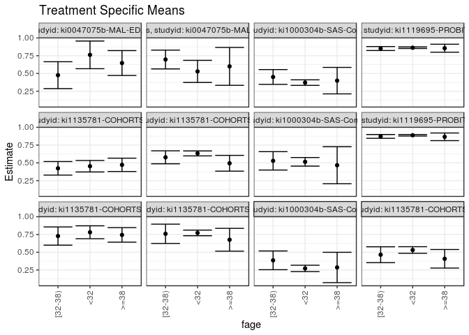

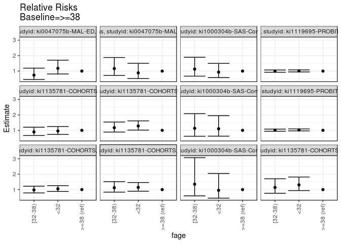

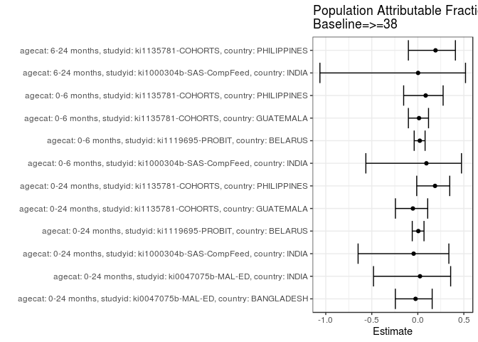

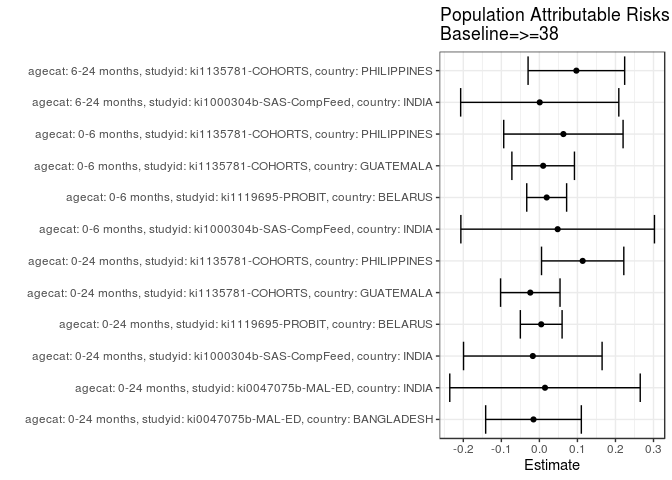

## Results Table

### Parameter: TSM

| agecat | studyid | country | intervention_level | baseline_level | estimate | ci_lower | ci_upper |
| --- | --- | --- | --- | --- | --- | --- | --- |
| 0-24 months | ki0047075b-MAL-ED | BANGLADESH | >=38 | NA | 0.6470588 | 0.4719757 | 0.8221420 |
| 0-24 months | ki0047075b-MAL-ED | BANGLADESH | <32 | NA | 0.7619048 | 0.5675039 | 0.9563056 |
| 0-24 months | ki0047075b-MAL-ED | BANGLADESH | [32-38) | NA | 0.4761905 | 0.2868777 | 0.6655032 |
| 0-24 months | ki0047075b-MAL-ED | INDIA | >=38 | NA | 0.6000000 | 0.3336484 | 0.8663516 |
| 0-24 months | ki0047075b-MAL-ED | INDIA | <32 | NA | 0.5294118 | 0.3739682 | 0.6848553 |
| 0-24 months | ki0047075b-MAL-ED | INDIA | [32-38) | NA | 0.6964286 | 0.5644321 | 0.8284250 |
| 0-24 months | ki1000304b-SAS-CompFeed | INDIA | >=38 | NA | 0.3995279 | 0.2134348 | 0.5856210 |
| 0-24 months | ki1000304b-SAS-CompFeed | INDIA | <32 | NA | 0.3719313 | 0.3328890 | 0.4109736 |
| 0-24 months | ki1000304b-SAS-CompFeed | INDIA | [32-38) | NA | 0.4509047 | 0.3469086 | 0.5549009 |
| 0-24 months | ki1119695-PROBIT | BELARUS | >=38 | NA | 0.8552823 | 0.7991715 | 0.9113931 |
| 0-24 months | ki1119695-PROBIT | BELARUS | <32 | NA | 0.8625215 | 0.8511657 | 0.8738774 |
| 0-24 months | ki1119695-PROBIT | BELARUS | [32-38) | NA | 0.8508959 | 0.8231116 | 0.8786802 |
| 0-24 months | ki1135781-COHORTS | GUATEMALA | >=38 | NA | 0.4719731 | 0.3780911 | 0.5658551 |
| 0-24 months | ki1135781-COHORTS | GUATEMALA | <32 | NA | 0.4525713 | 0.3719138 | 0.5332288 |
| 0-24 months | ki1135781-COHORTS | GUATEMALA | [32-38) | NA | 0.4230087 | 0.3274547 | 0.5185626 |
| 0-24 months | ki1135781-COHORTS | PHILIPPINES | >=38 | NA | 0.4942559 | 0.3834251 | 0.6050867 |
| 0-24 months | ki1135781-COHORTS | PHILIPPINES | <32 | NA | 0.6327873 | 0.5979632 | 0.6676115 |
| 0-24 months | ki1135781-COHORTS | PHILIPPINES | [32-38) | NA | 0.5780595 | 0.4869687 | 0.6691504 |
| 0-6 months | ki1000304b-SAS-CompFeed | INDIA | >=38 | NA | 0.4666667 | 0.2061538 | 0.7271796 |
| 0-6 months | ki1000304b-SAS-CompFeed | INDIA | <32 | NA | 0.5147059 | 0.4543062 | 0.5751055 |
| 0-6 months | ki1000304b-SAS-CompFeed | INDIA | [32-38) | NA | 0.5283019 | 0.3989989 | 0.6576049 |
| 0-6 months | ki1119695-PROBIT | BELARUS | >=38 | NA | 0.8660906 | 0.8124921 | 0.9196892 |
| 0-6 months | ki1119695-PROBIT | BELARUS | <32 | NA | 0.8882068 | 0.8774241 | 0.8989895 |
| 0-6 months | ki1119695-PROBIT | BELARUS | [32-38) | NA | 0.8719887 | 0.8454097 | 0.8985678 |
| 0-6 months | ki1135781-COHORTS | GUATEMALA | >=38 | NA | 0.7436773 | 0.6415332 | 0.8458215 |
| 0-6 months | ki1135781-COHORTS | GUATEMALA | <32 | NA | 0.7808988 | 0.6901142 | 0.8716834 |
| 0-6 months | ki1135781-COHORTS | GUATEMALA | [32-38) | NA | 0.7276374 | 0.5995135 | 0.8557613 |
| 0-6 months | ki1135781-COHORTS | PHILIPPINES | >=38 | NA | 0.6753336 | 0.5148839 | 0.8357833 |
| 0-6 months | ki1135781-COHORTS | PHILIPPINES | <32 | NA | 0.7717021 | 0.7322841 | 0.8111202 |
| 0-6 months | ki1135781-COHORTS | PHILIPPINES | [32-38) | NA | 0.7590809 | 0.6232341 | 0.8949277 |
| 6-24 months | ki1000304b-SAS-CompFeed | INDIA | >=38 | NA | 0.2857143 | 0.0723858 | 0.4990428 |
| 6-24 months | ki1000304b-SAS-CompFeed | INDIA | <32 | NA | 0.2722646 | 0.2273817 | 0.3171476 |
| 6-24 months | ki1000304b-SAS-CompFeed | INDIA | [32-38) | NA | 0.3859649 | 0.2542449 | 0.5176849 |
| 6-24 months | ki1135781-COHORTS | PHILIPPINES | >=38 | NA | 0.4077533 | 0.2771255 | 0.5383812 |
| 6-24 months | ki1135781-COHORTS | PHILIPPINES | <32 | NA | 0.5309985 | 0.4846190 | 0.5773779 |
| 6-24 months | ki1135781-COHORTS | PHILIPPINES | [32-38) | NA | 0.4647820 | 0.3529039 | 0.5766601 |

### Parameter: E(Y)

| agecat | studyid | country | intervention_level | baseline_level | estimate | ci_lower | ci_upper |
| --- | --- | --- | --- | --- | --- | --- | --- |
| 0-24 months | ki0047075b-MAL-ED | BANGLADESH | NA | NA | 0.6315789 | 0.5193816 | 0.7437763 |
| 0-24 months | ki0047075b-MAL-ED | INDIA | NA | NA | 0.6147541 | 0.5199078 | 0.7096004 |
| 0-24 months | ki1000304b-SAS-CompFeed | INDIA | NA | NA | 0.3822441 | 0.3470990 | 0.4173892 |
| 0-24 months | ki1119695-PROBIT | BELARUS | NA | NA | 0.8600988 | 0.8497563 | 0.8704412 |
| 0-24 months | ki1135781-COHORTS | GUATEMALA | NA | NA | 0.4480874 | 0.3954108 | 0.5007641 |
| 0-24 months | ki1135781-COHORTS | PHILIPPINES | NA | NA | 0.6080247 | 0.5830213 | 0.6330281 |
| 0-6 months | ki1000304b-SAS-CompFeed | INDIA | NA | NA | 0.5147059 | 0.4610948 | 0.5683169 |
| 0-6 months | ki1119695-PROBIT | BELARUS | NA | NA | 0.8852740 | 0.8754291 | 0.8951189 |
| 0-6 months | ki1135781-COHORTS | GUATEMALA | NA | NA | 0.7536232 | 0.6949302 | 0.8123162 |
| 0-6 months | ki1135781-COHORTS | PHILIPPINES | NA | NA | 0.7384615 | 0.7062339 | 0.7706892 |
| 6-24 months | ki1000304b-SAS-CompFeed | INDIA | NA | NA | 0.2866242 | 0.2446853 | 0.3285631 |
| 6-24 months | ki1135781-COHORTS | PHILIPPINES | NA | NA | 0.5049724 | 0.4705318 | 0.5394130 |

### Parameter: RR

| agecat | studyid | country | intervention_level | baseline_level | estimate | ci_lower | ci_upper |
| --- | --- | --- | --- | --- | --- | --- | --- |
| 0-24 months | ki0047075b-MAL-ED | BANGLADESH | >=38 | >=38 | 1.0000000 | 1.0000000 | 1.000000 |
| 0-24 months | ki0047075b-MAL-ED | BANGLADESH | <32 | >=38 | 1.1774892 | 0.8118096 | 1.707889 |
| 0-24 months | ki0047075b-MAL-ED | BANGLADESH | [32-38) | >=38 | 0.7359307 | 0.4549883 | 1.190347 |
| 0-24 months | ki0047075b-MAL-ED | INDIA | >=38 | >=38 | 1.0000000 | 1.0000000 | 1.000000 |
| 0-24 months | ki0047075b-MAL-ED | INDIA | <32 | >=38 | 0.8823529 | 0.5176350 | 1.504046 |
| 0-24 months | ki0047075b-MAL-ED | INDIA | [32-38) | >=38 | 1.1607143 | 0.7166205 | 1.880016 |
| 0-24 months | ki1000304b-SAS-CompFeed | INDIA | >=38 | >=38 | 1.0000000 | 1.0000000 | 1.000000 |
| 0-24 months | ki1000304b-SAS-CompFeed | INDIA | <32 | >=38 | 0.9309271 | 0.5777685 | 1.499952 |
| 0-24 months | ki1000304b-SAS-CompFeed | INDIA | [32-38) | >=38 | 1.1285939 | 0.6715202 | 1.896777 |
| 0-24 months | ki1119695-PROBIT | BELARUS | >=38 | >=38 | 1.0000000 | 1.0000000 | 1.000000 |
| 0-24 months | ki1119695-PROBIT | BELARUS | <32 | >=38 | 1.0084641 | 0.9432213 | 1.078220 |
| 0-24 months | ki1119695-PROBIT | BELARUS | [32-38) | >=38 | 0.9948714 | 0.9246012 | 1.070482 |
| 0-24 months | ki1135781-COHORTS | GUATEMALA | >=38 | >=38 | 1.0000000 | 1.0000000 | 1.000000 |
| 0-24 months | ki1135781-COHORTS | GUATEMALA | <32 | >=38 | 0.9588922 | 0.7372815 | 1.247114 |
| 0-24 months | ki1135781-COHORTS | GUATEMALA | [32-38) | >=38 | 0.8962559 | 0.6676446 | 1.203147 |
| 0-24 months | ki1135781-COHORTS | PHILIPPINES | >=38 | >=38 | 1.0000000 | 1.0000000 | 1.000000 |
| 0-24 months | ki1135781-COHORTS | PHILIPPINES | <32 | >=38 | 1.2802829 | 1.0163748 | 1.612716 |
| 0-24 months | ki1135781-COHORTS | PHILIPPINES | [32-38) | >=38 | 1.1695552 | 0.8891816 | 1.538335 |
| 0-6 months | ki1000304b-SAS-CompFeed | INDIA | >=38 | >=38 | 1.0000000 | 1.0000000 | 1.000000 |
| 0-6 months | ki1000304b-SAS-CompFeed | INDIA | <32 | >=38 | 1.1029412 | 0.6234654 | 1.951158 |
| 0-6 months | ki1000304b-SAS-CompFeed | INDIA | [32-38) | >=38 | 1.1320755 | 0.6153979 | 2.082547 |
| 0-6 months | ki1119695-PROBIT | BELARUS | >=38 | >=38 | 1.0000000 | 1.0000000 | 1.000000 |
| 0-6 months | ki1119695-PROBIT | BELARUS | <32 | >=38 | 1.0255356 | 0.9628647 | 1.092286 |
| 0-6 months | ki1119695-PROBIT | BELARUS | [32-38) | >=38 | 1.0068100 | 0.9396956 | 1.078718 |
| 0-6 months | ki1135781-COHORTS | GUATEMALA | >=38 | >=38 | 1.0000000 | 1.0000000 | 1.000000 |
| 0-6 months | ki1135781-COHORTS | GUATEMALA | <32 | >=38 | 1.0500505 | 0.8774281 | 1.256634 |
| 0-6 months | ki1135781-COHORTS | GUATEMALA | [32-38) | >=38 | 0.9784316 | 0.7830517 | 1.222561 |
| 0-6 months | ki1135781-COHORTS | PHILIPPINES | >=38 | >=38 | 1.0000000 | 1.0000000 | 1.000000 |
| 0-6 months | ki1135781-COHORTS | PHILIPPINES | <32 | >=38 | 1.1426978 | 0.8963160 | 1.456806 |
| 0-6 months | ki1135781-COHORTS | PHILIPPINES | [32-38) | >=38 | 1.1240088 | 0.8348669 | 1.513290 |
| 6-24 months | ki1000304b-SAS-CompFeed | INDIA | >=38 | >=38 | 1.0000000 | 1.0000000 | 1.000000 |
| 6-24 months | ki1000304b-SAS-CompFeed | INDIA | <32 | >=38 | 0.9529262 | 0.4435900 | 2.047089 |
| 6-24 months | ki1000304b-SAS-CompFeed | INDIA | [32-38) | >=38 | 1.3508772 | 0.5944071 | 3.070066 |
| 6-24 months | ki1135781-COHORTS | PHILIPPINES | >=38 | >=38 | 1.0000000 | 1.0000000 | 1.000000 |
| 6-24 months | ki1135781-COHORTS | PHILIPPINES | <32 | >=38 | 1.3022541 | 0.9340003 | 1.815701 |
| 6-24 months | ki1135781-COHORTS | PHILIPPINES | [32-38) | >=38 | 1.1398607 | 0.7631252 | 1.702581 |

### Parameter: PAR

| agecat | studyid | country | intervention_level | baseline_level | estimate | ci_lower | ci_upper |
| --- | --- | --- | --- | --- | --- | --- | --- |
| 0-24 months | ki0047075b-MAL-ED | BANGLADESH | >=38 | NA | -0.0154799 | -0.1412234 | 0.1102637 |
| 0-24 months | ki0047075b-MAL-ED | INDIA | >=38 | NA | 0.0147541 | -0.2355840 | 0.2650922 |
| 0-24 months | ki1000304b-SAS-CompFeed | INDIA | >=38 | NA | -0.0172837 | -0.1994105 | 0.1648430 |
| 0-24 months | ki1119695-PROBIT | BELARUS | >=38 | NA | 0.0048164 | -0.0500620 | 0.0596948 |
| 0-24 months | ki1135781-COHORTS | GUATEMALA | >=38 | NA | -0.0238857 | -0.1020344 | 0.0542630 |
| 0-24 months | ki1135781-COHORTS | PHILIPPINES | >=38 | NA | 0.1137688 | 0.0056112 | 0.2219264 |
| 0-6 months | ki1000304b-SAS-CompFeed | INDIA | >=38 | NA | 0.0480392 | -0.2064266 | 0.3025050 |
| 0-6 months | ki1119695-PROBIT | BELARUS | >=38 | NA | 0.0191833 | -0.0332393 | 0.0716059 |
| 0-6 months | ki1135781-COHORTS | GUATEMALA | >=38 | NA | 0.0099458 | -0.0722910 | 0.0921827 |
| 0-6 months | ki1135781-COHORTS | PHILIPPINES | >=38 | NA | 0.0631280 | -0.0937526 | 0.2200085 |
| 6-24 months | ki1000304b-SAS-CompFeed | INDIA | >=38 | NA | 0.0009099 | -0.2069616 | 0.2087814 |
| 6-24 months | ki1135781-COHORTS | PHILIPPINES | >=38 | NA | 0.0972190 | -0.0297285 | 0.2241666 |

### Parameter: PAF

| agecat | studyid | country | intervention_level | baseline_level | estimate | ci_lower | ci_upper |
| --- | --- | --- | --- | --- | --- | --- | --- |
| 0-24 months | ki0047075b-MAL-ED | BANGLADESH | >=38 | NA | -0.0245098 | -0.2439004 | 0.1561862 |
| 0-24 months | ki0047075b-MAL-ED | INDIA | >=38 | NA | 0.0240000 | -0.4812659 | 0.3569176 |
| 0-24 months | ki1000304b-SAS-CompFeed | INDIA | >=38 | NA | -0.0452165 | -0.6487645 | 0.3373963 |
| 0-24 months | ki1119695-PROBIT | BELARUS | >=38 | NA | 0.0055999 | -0.0602983 | 0.0674024 |
| 0-24 months | ki1135781-COHORTS | GUATEMALA | >=38 | NA | -0.0533058 | -0.2431748 | 0.1075646 |
| 0-24 months | ki1135781-COHORTS | PHILIPPINES | >=38 | NA | 0.1871122 | -0.0118720 | 0.3469662 |
| 0-6 months | ki1000304b-SAS-CompFeed | INDIA | >=38 | NA | 0.0933333 | -0.5644012 | 0.4745309 |
| 0-6 months | ki1119695-PROBIT | BELARUS | >=38 | NA | 0.0216694 | -0.0393831 | 0.0791357 |
| 0-6 months | ki1135781-COHORTS | GUATEMALA | >=38 | NA | 0.0131974 | -0.1022189 | 0.1165281 |
| 0-6 months | ki1135781-COHORTS | PHILIPPINES | >=38 | NA | 0.0854858 | -0.1537439 | 0.2751111 |
| 6-24 months | ki1000304b-SAS-CompFeed | INDIA | >=38 | NA | 0.0031746 | -1.0634622 | 0.5184497 |
| 6-24 months | ki1135781-COHORTS | PHILIPPINES | >=38 | NA | 0.1925235 | -0.1023834 | 0.4085376 |